# Make plots for PRTB transformation Figure 1

Joe Bowness

February 06, 2026

Abstract

This is a record of performing nearest-neighbour correction (ie generating PRTB assay) on the CRISPRi500 HSC data set. Plots demonstrate how the PRTB transformation accounts for heterogeneity in the data set and emphasises correlations in pseudobulks between guides which target the same gene for CRISPRi. I then define the SGS score (Same Gene Similarity) for each perturbation, and use this to justify subsetting the data set to only perturbations which show consistent effects between the guide replicates.

## 0.1 Required packages

```r
knitr::opts_chunk$set(message = FALSE, warning = FALSE)

library(readr)
library(dplyr)
library(ggplot2)
library(patchwork)
library(Seurat)
library(corrplot)
library(future)
library(ggrepel)
library(mclust)

options(future.globals.maxSize = 15 * 1024^3)
```

## 0.2 Load and modify seurat object

- Although we excluded them in differential expression analysis, I decided **not to exclude** NT10 and NT12 from the set of control guide RNAs for calculating prtb scores.
- This is based on the assumption that the abnormal patterns from NT10 and NT12 are due to clonal expansions, and not because the NT guides have true effects. Neighbour-correction should account for the clonal effect, so there is no reason to exclude them as control cells…

```r
CRISPRi500_HSC_WTx <- readRDS("~/cluster/jbowness/CRISPRi500/HSC/clean_analysis/seurat_objects/CRISPRi500_HSC_WTx_corrected.RDS")

# make singletarget column
CRISPRi500_HSC_WTx@meta.data$singletarget <- sub("-.*", "", CRISPRi500_HSC_WTx@meta.data$single_guides)
CRISPRi500_HSC_WTx@meta.data$singletarget[grepl("NO|ONE", CRISPRi500_HSC_WTx@meta.data$singletarget)] <- "Non-targeting"

# This would remove NO-SITE-sgRNA-10 NO-SITE-sgRNA-12 from controls and have them separate in the 'singletarget' column
#CRISPRi500_HSC_WTx$singletarget[CRISPRi500_HSC_WTx$single_guides == "NO-SITE-sgRNA-10"] <- "NO-SITE-sgRNA-10"
#CRISPRi500_HSC_WTx$singletarget[CRISPRi500_HSC_WTx$single_guides == "NO-SITE-sgRNA-12"] <- "NO-SITE-sgRNA-12"

# Make single_guides_for_prtb column (make all controls "Non-targeting")
CRISPRi500_HSC_WTx$single_guides_for_prtb <- CRISPRi500_HSC_WTx$single_guides
CRISPRi500_HSC_WTx$single_guides_for_prtb[CRISPRi500_HSC_WTx$singletarget == "Non-targeting"] <- "Non-targeting"

# Make cells without guides NA instead of ""
CRISPRi500_HSC_WTx$single_guides[CRISPRi500_HSC_WTx$single_guides == ""] <- NA
```

# 1 PRTB TRANSFORMATION

## 1.1 Select genes for PRTB assay

- Take 10 most DE genes for each perturbation
- 1000 most variable genes in seurat assay
- Filter to only keep genes that have > 0.25 UMIs per cell
- Changing the DE results from 2PCs to default -> 2289 genes are the same, 400 only in default, 586 only in 2PC

```r
generate_features_to_include <- function(
  seurat_obj,
  path_5X,
  path_Rem,
  num_de_genes_to_choose_5X = 10,
  num_de_genes_to_choose_Rem = 10,
  num_var_genes_to_choose = 1000,
  umi_threshold = 0.25,
  assay = "SCT"
) {
  # --- read differential expression results ---
  de_5X  <- readRDS(path_5X)
  de_Rem <- readRDS(path_Rem)

  # --- top DE genes per perturbation target ---
  de_5X_top <- de_5X %>%
    group_by(grna_target) %>%
    arrange(p_value) %>%
    slice_head(n = num_de_genes_to_choose_5X) %>%
    ungroup()

  de_Rem_top <- de_Rem %>%
    group_by(grna_target) %>%
    arrange(p_value) %>%
    slice_head(n = num_de_genes_to_choose_Rem) %>%
    filter(!is.na(p_value)) %>%
    ungroup()

  perturb_de_genes <- unique(c(de_5X_top$response_id, de_Rem_top$response_id))

  # --- top variable genes across assay ---
  seurat_obj <- FindVariableFeatures(
    object = seurat_obj,
    assay = assay,
    nfeatures = num_var_genes_to_choose
  )
  top_var_genes <- VariableFeatures(seurat_obj, assay = assay)

  # --- UMI filter (> threshold UMIs per cell) ---
  umi_means <- rowMeans(seurat_obj@assays[[assay]]@counts)
  umi_pass  <- names(umi_means[umi_means > umi_threshold])

  top_var_genes_umi_filtered <- intersect(top_var_genes, umi_pass)

  # --- combine DE + variable ---
  features_to_include <- unique(c(perturb_de_genes, top_var_genes_umi_filtered))

  message("Selected ", length(features_to_include), " total features.")
  return(features_to_include)
}

# these are features I was using before
features_to_include_2PC <- generate_features_to_include(
  seurat_obj = CRISPRi500_HSC_WTx,
  path_5X = "~/cluster/jbowness/CRISPRi500/HSC/clean_analysis/sceptre/sceptre_outputs/CRISPRi500_HSC_Rep1_5X_rmNT10_2PC/results_run_discovery_analysis.rds",
  path_Rem = "~/cluster/jbowness/CRISPRi500/HSC/clean_analysis/sceptre/sceptre_outputs/CRISPRi500_HSC_Rep1_Rem_rmNT12_2PC/results_run_discovery_analysis.rds"
)

# these are features when using DE without covariate correction
features_to_include_default <- generate_features_to_include(
  seurat_obj = CRISPRi500_HSC_WTx,
  path_5X = "~/cluster/jbowness/CRISPRi500/HSC/clean_analysis/sceptre/sceptre_outputs/CRISPRi500_HSC_Rep1_5X_rmNT10_default/results_run_discovery_analysis.rds",
  path_Rem = "~/cluster/jbowness/CRISPRi500/HSC/clean_analysis/sceptre/sceptre_outputs/CRISPRi500_HSC_Rep1_Rem_rmNT12_default/results_run_discovery_analysis.rds"
)
```

## 1.2 Choose which features_to_include

```r
# choose either the default or the 2PC features_to_include
features_to_include <- features_to_include_default
#features_to_include <- features_to_include_2PC
```

## 1.3 Perform the PRTB correction

- The transcriptome of each cell is normalised by subtracting that cell from the average of its 20 nearest neighbours control cells ie. Exp(neighbours) - Exp(perturbed cell). This is done in log1p space.
- This means that a repressed gene (ie. the target gene of the guide), which has lower counts in the perturbed cell than its neighbours, becomes transformed into a positive value.
- Control cells are defined by the labels of “Non-targeting” in the “single_guides” column (ie. these are cells where only 1 unique control guide RNA was detected)
- Nearest neighbours are found in 40 dimensions of PCA space
- All cells, included cells without guides and control cells themselves, are subject to this same procedure
- PRTB scores are centred as suggested in https://satijalab.org/seurat/archive/v4.3/mixscape_vignette

```r
# set default assay to SCT (we use the "data" slot, which contains log1p-normalised 'corrected' counts)
DefaultAssay(CRISPRi500_HSC_WTx) <- "SCT"

# this is the calculation of the perturbation signature
CRISPRi500_HSC_WTx <- CalcPerturbSig(
  object = CRISPRi500_HSC_WTx,
  features = features_to_include,
  assay = "SCT",
  slot = "data",
  gd.class ="single_guides_for_prtb",
  nt.cell.class = "Non-targeting",
  reduction = "pca",
  ndims = 40,
  num.neighbors = 20,
  new.assay.name = "prtb",
  verbose=TRUE)

plot(density(colMeans(CRISPRi500_HSC_WTx@assays[["prtb"]]@data)))

#Scale and centre the prtb assay - regress out library size covariatates
CRISPRi500_HSC_WTx <- ScaleData(CRISPRi500_HSC_WTx,
                                  assay = "prtb",
                                vars.to.regress = c("nCount_RNA", "nFeature_RNA"),
                                do.scale = F,
                                do.center = T,
                                verbose = TRUE)
plot(density(colMeans(CRISPRi500_HSC_WTx@assays[["prtb"]]@scale.data)))
```

## 1.4 Make prtb pseudobulk

```r
# Average expression from prtb assay in seurat object over features
perturbations_by_features_guide_prtb <- Seurat::AverageExpression(CRISPRi500_HSC_WTx,
                                                 assays = "prtb",
                                                 layer = "scale.data",
                                                 group.by = "single_guides",
                                                 verbose=TRUE)
perturbations_by_features_guide_prtb <- as.data.frame(perturbations_by_features_guide_prtb)

#remove prtb from col names
colnames(perturbations_by_features_guide_prtb) <- gsub("^prtb\\.", "", colnames(perturbations_by_features_guide_prtb))
#remove .CRISPRi.sgRNA. from col names
colnames(perturbations_by_features_guide_prtb) <- sub(".CRISPRi.sgRNA*", "", colnames(perturbations_by_features_guide_prtb))

### look at what the prtb scores are for Mecom upon Mecom perturbation (expression goes down) and Atf7ip upon Setdb1 perturbation (expression goes up)
perturbations_by_features_guide_prtb["Mecom",c("Mecom.1","Mecom.2","Mecom.3","NO.SITE.sgRNA.1","NO.SITE.sgRNA.2")]
perturbations_by_features_guide_prtb["Atf7ip",c("Setdb1.1","Setdb1.2","Setdb1.3","NO.SITE.sgRNA.1","NO.SITE.sgRNA.2")]

#remove perturbation itself from scores
for (row in rownames(perturbations_by_features_guide_prtb)) {
  for (col in colnames(perturbations_by_features_guide_prtb)) {
    if (grepl(row, col)) {
      perturbations_by_features_guide_prtb[row, col] <- 0
    }
  }
}
#now all 3 Mecom guides are turned to 0
perturbations_by_features_guide_prtb["Mecom",c("Mecom.1","Mecom.2","Mecom.3")]
```

## 1.5 Make paired SCT pseudobulk

- In order to properly compare the pseudobulks, we need to regenerate the SCT assay with same selected genes as used in the PRTB

```r
# Recompute SCT using the same variable genes used in prtb
recompute_SCT_with_custom_features <- function(seurat_obj,
                                               features_to_include,
                                               base_assay = "RNA",
                                               new_assay  = "SCT2",
                                               vars_to_regress = NULL,
                                               use_glmGamPoi = TRUE) {
  stopifnot(base_assay %in% names(seurat_obj@assays))
  DefaultAssay(seurat_obj) <- base_assay
  # 1) Keep only features present in the object
  feats <- intersect(features_to_include, rownames(seurat_obj[[base_assay]]))
  obj_sub <- DietSeurat(
    seurat_obj,
    assays = base_assay,
    counts = TRUE, data = TRUE,
    dimreducs = NULL, graphs = NULL
  )
  obj_sub <- subset(obj_sub, features = feats)


  # 2) Recompute SCT (keep all genes in the new assay so downstream markers work)
  obj_sub <- SCTransform(
    object = obj_sub,
    assay = base_assay,
    new.assay.name = "SCT_tmp",
    vars.to.regress = vars_to_regress,
    method = if (use_glmGamPoi) "glmGamPoi" else "poisson",
    return.only.var.genes = FALSE,   # keep all genes in SCT2
    verbose = TRUE
  )

  # 3) attach this SCT assay back to the full object as `new_assay"
  seurat_obj[[new_assay]] <- obj_sub[["SCT_tmp"]]
  VariableFeatures(seurat_obj, assay = new_assay) <- feats

  return(seurat_obj)
}
CRISPRi500_HSC_WTx <- recompute_SCT_with_custom_features(CRISPRi500_HSC_WTx, features_to_include)

# Average expression from SCT assay in seurat object over features
perturbations_by_features_guide_sct <- Seurat::AverageExpression(CRISPRi500_HSC_WTx,
                                                 assays = "SCT2",
                                                 layer = "scale.data",
                                                 group.by = "single_guides",
                                                 verbose = TRUE)
perturbations_by_features_guide_sct <- as.data.frame(perturbations_by_features_guide_sct)

#remove SCT from col names
colnames(perturbations_by_features_guide_sct) <- gsub("^SCT2\\.", "", colnames(perturbations_by_features_guide_sct))

#remove .CRISPRi.sgRNA. from col names
colnames(perturbations_by_features_guide_sct) <- sub(".CRISPRi.sgRNA*", "", colnames(perturbations_by_features_guide_sct))
perturbations_by_features_guide_sct["Mecom",c("Mecom.1","Mecom.2","Mecom.3","NO.SITE.sgRNA.1","NO.SITE.sgRNA.2")]
perturbations_by_features_guide_sct["Atf7ip",c("Setdb1.1","Setdb1.2","Setdb1.3","NO.SITE.sgRNA.1","NO.SITE.sgRNA.2")]

#remove perturbation itself from scores
for (row in rownames(perturbations_by_features_guide_sct)) {
  for (col in colnames(perturbations_by_features_guide_sct)) {
    if (grepl(row, col)) {
      perturbations_by_features_guide_sct[row, col] <- 0
    }
  }
}
#now all 3 Mecom guides are turned to 0
perturbations_by_features_guide_sct["Mecom",c("Mecom.1","Mecom.2","Mecom.3")]
```

## 1.6 save the features_to_include, the pseudobulks, and the updated seurat object

```r
write.csv(features_to_include_default,
          file = "manuscript/int_files/features_to_include_default.csv",
          row.names = FALSE)
write.csv(features_to_include_2PC,
          file = "manuscript/int_files/features_to_include_2PC.csv",
          row.names = FALSE)

write.csv(perturbations_by_features_guide_sct,
          file = "manuscript/int_files/perturbations_by_features_guide_sct.csv",
          row.names = FALSE)
write.csv(perturbations_by_features_guide_prtb,
          file = "manuscript/int_files/perturbations_by_features_guide_prtb.csv",
          row.names = FALSE)

# with rownames
write.csv(perturbations_by_features_guide_sct,
          file = "manuscript/int_files/perturbations_by_features_guide_sct_rownames.csv",
          row.names = TRUE)
write.csv(perturbations_by_features_guide_prtb,
          file = "manuscript/int_files/perturbations_by_features_guide_prtb_rownames.csv",
          row.names = TRUE)


saveRDS(CRISPRi500_HSC_WTx, file = "/home/jbowness/cluster/jbowness/CRISPRi500/HSC/clean_analysis/seurat_objects/CRISPRi500_HSC_WTx_prtb.RDS")
```

## 1.7 UMAPs before and after PRTB

```r
# re-load in seurat object, now with PRTB assay
CRISPRi500_HSC_WTx <- readRDS("~/cluster/jbowness/CRISPRi500/HSC/clean_analysis/seurat_objects/CRISPRi500_HSC_WTx_prtb.RDS")

# load features_to include
features_to_include <- read_csv("/home/jbowness/cluster/jbowness/CRISPRi500/HSC/clean_analysis/manuscript/int_files/features_to_include_default.csv")$"x"
```

- In testing this, I also ran the PCA with ‘jackstraw = TRUE’, but this requires you to store the reduction with the default ‘pca’ name.
- Performing JackStraw() and ScoreJackStraw() on a subsampled data set (10k cells) definitively showed that PCs beyond 20 are not significant.
- Inferences from the Elbowplot vary from PC7 to PC11. It looks like there are 3 elbows in the plot at ~PC9, ~PC12 and PC19.
- I decide to use 15 PCs for the UMAP

```r
#PCA and cluster based on prtb
DefaultAssay(CRISPRi500_HSC_WTx) <- 'prtb'

# Use variable features features_to_include
VariableFeatures(CRISPRi500_HSC_WTx) <- features_to_include

# Run PCA to reduce the dimensionality of the data.
CRISPRi500_HSC_WTx <- RunPCA(CRISPRi500_HSC_WTx,
                             npcs = 50,
                             reduction.key = 'prtbpca',
                             reduction.name = 'prtbpca',
                             verbose = TRUE)
```

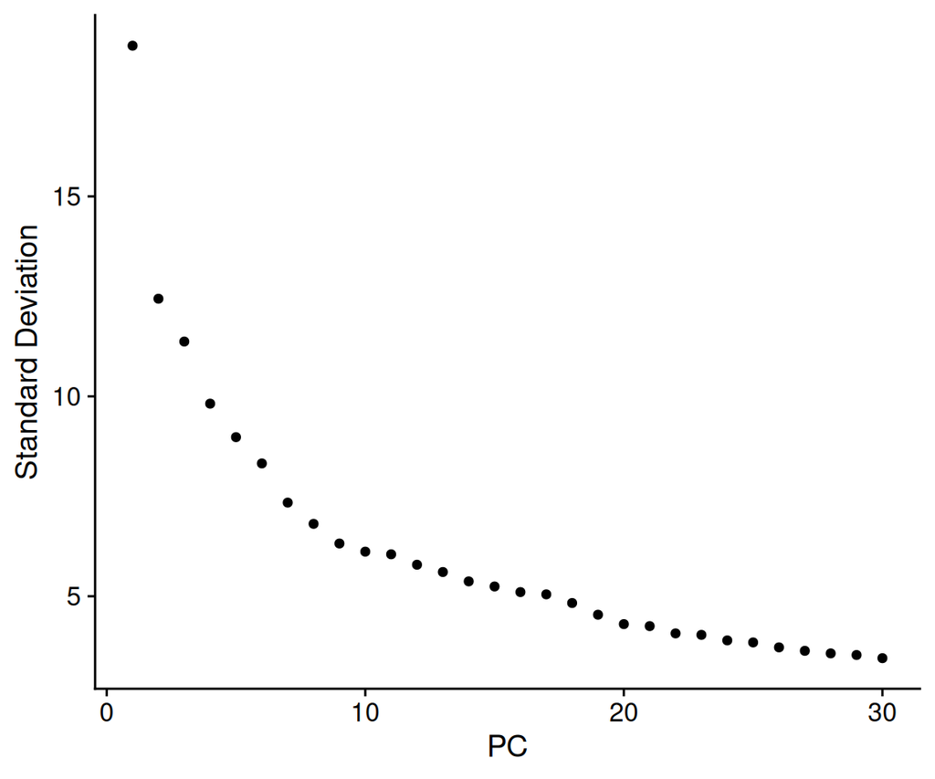

```r
# How many PCs to use for UMAP?
ElbowPlot(CRISPRi500_HSC_WTx, ndims = 30)
```

```r
# "Programmatic elbow" = PC7
find_elbow <- function(stdev, ndims = 50, smooth = TRUE) {
  x <- 1:ndims
  y <- stdev[1:ndims]^2  # variance explained (unnormalized is fine)
  if (smooth) y <- stats::predict(stats::loess(y ~ x, span = 0.3))
  x1 <- x[1]; y1 <- y[1]; x2 <- x[ndims]; y2 <- y[ndims]
  dist <- abs((y2 - y1)*x - (x2 - x1)*y + x2*y1 - y2*x1) / sqrt((y2 - y1)^2 + (x2 - x1)^2)
  which.max(dist)
}
stdev <- CRISPRi500_HSC_WTx[["prtbpca"]]@stdev
npcs  <- find_elbow(stdev, ndims = 50)
npcs
```

```
## [1] 7
```

```r
# "2nd derivative elbow" = PC11
pct <- (stdev^2) / sum(stdev^2) * 100
y   <- pct[1:50]
k   <- which.max(-diff(y, differences = 2)) + 2
k
```

```
## [1] 11
```

```r
# Run UMAP to visualize clustering in 2-D.
CRISPRi500_HSC_WTx <- RunUMAP(
  object = CRISPRi500_HSC_WTx,
  dims = 1:15,
  reduction = 'prtbpca',
  reduction.key = 'prtbumap',
  reduction.name = 'prtbumap')

# Change default assay back to SCT
DefaultAssay(CRISPRi500_HSC_WTx) <- 'SCT'
```

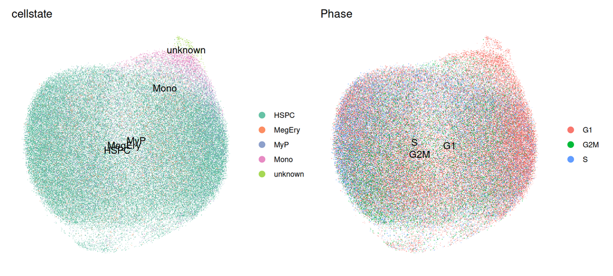

```r
# UMAPs by cell state or cell cycle
cellstate_after <- DimPlot(CRISPRi500_HSC_WTx,
                           reduction = "prtbumap", group.by = 'cellstate', label=TRUE) +
  scale_color_brewer(palette = "Set2") +
  theme_minimal() +
  theme(axis.title = element_blank(),
        axis.text = element_blank(),
        axis.ticks = element_blank(),
        panel.grid.major = element_blank(), panel.grid.minor = element_blank())

cellcycle_after <- DimPlot(CRISPRi500_HSC_WTx,
                           reduction = "prtbumap", group.by = 'Phase', label=TRUE) +
  theme_minimal() +
  theme(axis.title = element_blank(),
        axis.text = element_blank(),
        axis.ticks = element_blank(),
        panel.grid.major = element_blank(), panel.grid.minor = element_blank())

cellstate_after + cellcycle_after
```

```r
# save plot
ggsave( filename = "manuscript/figs/prtb_umap_cellstate.pdf",
        plot     = cellstate_after,
        width    = 5.5,
        height   = 5,
        units    = "in"
        )
ggsave( filename = "manuscript/figs/prtb_umap_cellcycle.pdf",
        plot     = cellcycle_after,
        width    = 5.5,
        height   = 5,
        units    = "in"
        )
```

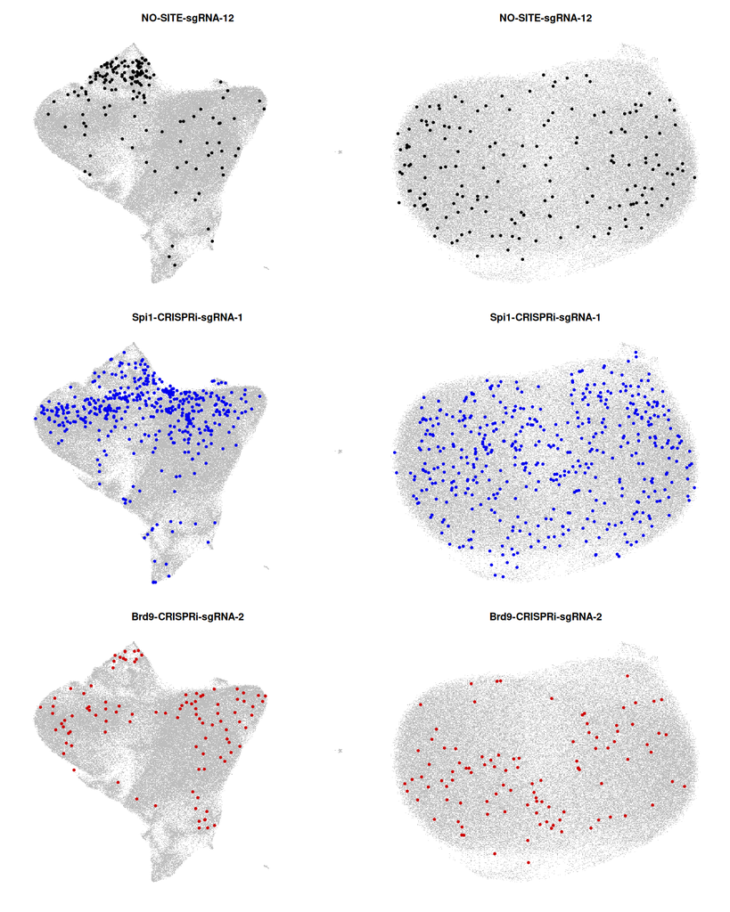

```r
# function to plot UMAP by guide (standard and prtb)
plot_umap_named_guide <- function(seurat_obj, guide_id, colour){
        seurat_obj$contains_target_guide <- grepl(guide_id, seurat_obj$guide_idents)
        #plot umap
        umap_plot <- DimPlot(seurat_obj,
                          reduction = "umap",
                          group.by = "contains_target_guide",
                          cols = c("grey", colour), label = FALSE)
        umap_plot <- umap_plot +
          geom_point(data = subset(umap_plot$data, contains_target_guide == TRUE),
                 aes(x = umap_1, y = umap_2),
                 color = colour, size = 0.5) +
      ggtitle(guide_id) +
      theme_minimal() +
      theme(legend.position = "none",
        axis.title = element_blank(), axis.text = element_blank(), axis.ticks = element_blank(),
        panel.grid.major = element_blank(), panel.grid.minor = element_blank(),
        plot.title = element_text(hjust = 0.5,  face = "bold", size = 8))
        return(umap_plot)
        }
plot_umap_named_guide_prtb <- function(seurat_obj, guide_id, colour){
        seurat_obj$contains_target_guide <- grepl(guide_id, seurat_obj$guide_idents)
        #plot umap
        umap_plot <- DimPlot(seurat_obj,
                          reduction = "prtbumap",
                          group.by = "contains_target_guide",
                          cols = c("grey", colour), label = FALSE)
        umap_plot <- umap_plot +
          geom_point(data = subset(umap_plot$data, contains_target_guide == TRUE),
                 aes(x = prtbumap_1, y = prtbumap_2),
                 color = colour, size = 0.5) +
      ggtitle(guide_id) +
      theme_minimal() +
      theme(legend.position = "none",
        axis.title = element_blank(), axis.text = element_blank(), axis.ticks = element_blank(),
        panel.grid.major = element_blank(), panel.grid.minor = element_blank(),
        plot.title = element_text(hjust = 0.5,  face = "bold", size = 8))
        return(umap_plot)
}

# UMAPs for 2 example guides
NT12_before <- plot_umap_named_guide(CRISPRi500_HSC_WTx, "NO-SITE-sgRNA-12","black")
NT12_after <- plot_umap_named_guide_prtb(CRISPRi500_HSC_WTx, "NO-SITE-sgRNA-12","black")
Dnmt3a_1_before <- plot_umap_named_guide(CRISPRi500_HSC_WTx, "Dnmt3a-CRISPRi-sgRNA-1","darkgreen")
Dnmt3a_1_after <- plot_umap_named_guide_prtb(CRISPRi500_HSC_WTx, "Dnmt3a-CRISPRi-sgRNA-1","darkgreen")
Spi1_1_before <- plot_umap_named_guide(CRISPRi500_HSC_WTx, "Spi1-CRISPRi-sgRNA-1","blue2")
Spi1_1_after <- plot_umap_named_guide_prtb(CRISPRi500_HSC_WTx, "Spi1-CRISPRi-sgRNA-1","blue2")
Brd9_2_before <- plot_umap_named_guide(CRISPRi500_HSC_WTx, "Brd9-CRISPRi-sgRNA-2","red3")
Brd9_2_after <- plot_umap_named_guide_prtb(CRISPRi500_HSC_WTx, "Brd9-CRISPRi-sgRNA-2","red3")

prtb_plots_list <- list()
prtb_plots_list[["NT12_before"]] <- NT12_before
prtb_plots_list[["NT12_after"]] <- NT12_after
#prtb_plots_list[["Dnmt3a_1_before"]] <- Dnmt3a_1_before
#prtb_plots_list[["Dnmt3a_1_after"]] <- Dnmt3a_1_after
prtb_plots_list[["Spi1_1_before"]] <- Spi1_1_before
prtb_plots_list[["Spi1_1_after"]] <- Spi1_1_after
prtb_plots_list[["Brd9_2_before"]] <- Brd9_2_before
prtb_plots_list[["Brd9_2_after"]] <- Brd9_2_after

final_prtb_umap <- wrap_plots(plotlist = prtb_plots_list, ncol = 2, nrow = 3)
final_prtb_umap
```

```r
# save plot
ggsave( filename = "manuscript/figs/prtb_umap_exampleguides.pdf",
        plot     = final_prtb_umap,
        width    = 7,
        height   = 9.4,
        units    = "in"
        )
```

# 2 Within-gene correlations before/after PRTB transformation

## 2.1 Load matrices of pseudobulks by perturbation:

```r
# These are features included in prtb assay
features_to_include <- read_csv("/home/jbowness/cluster/jbowness/CRISPRi500/HSC/clean_analysis/manuscript/int_files/features_to_include_default.csv")$"x"
#features_to_include <- read_csv("manuscript/int_files/features_to_include_2PC.csv")$"x"

# perturbation-by-feature matrix before prtb transformation
perturbations_by_features_guide_sct <- read_csv("/home/jbowness/cluster/jbowness/CRISPRi500/HSC/clean_analysis/manuscript/int_files/perturbations_by_features_guide_sct.csv")

# perturbation-by-feature matrix after prtb transformation
perturbations_by_features_guide_prtb <- read_csv("/home/jbowness/cluster/jbowness/CRISPRi500/HSC/clean_analysis/manuscript/int_files/perturbations_by_features_guide_prtb.csv")
```

## 2.2 Make correlation and distance matrices

```r
# ---- SPEARMAN correlation matrices ----
perturbation_guide_cormatrix_sct_spearman <- cor(perturbations_by_features_guide_sct,
                             method = c("spearman"))
perturbation_guide_cormatrix_prtb_spearman <- cor(perturbations_by_features_guide_prtb,
                             method = c("spearman"))

# Sanity checks that matricess are different
#head(perturbations_by_features_guide_sct[1:5,1:5])
#head(perturbation_guide_cormatrix_sct[1:5,1:5])

#head(perturbations_by_features_guide_prtb[1:5,1:5])
#head(perturbation_guide_cormatrix_prtb[1:5,1:5])

# convert cor matrices to distance matrices (1 - correlation)
perturbation_guide_distmatrix_sct_spearman <- as.matrix(as.dist(1 - perturbation_guide_cormatrix_sct_spearman))
perturbation_guide_distmatrix_prtb_spearman <- as.matrix(as.dist(1 - perturbation_guide_cormatrix_prtb_spearman))

# ---- PEARSON correlation matrices ----
perturbation_guide_cormatrix_sct_pearson <- cor(perturbations_by_features_guide_sct,
                             method = c("pearson"))
perturbation_guide_cormatrix_prtb_pearson <- cor(perturbations_by_features_guide_prtb,
                             method = c("pearson"))

# convert cor matrices to distance matrices (1 - correlation)
perturbation_guide_distmatrix_sct_pearson <- as.matrix(as.dist(1 - perturbation_guide_cormatrix_sct_pearson))
perturbation_guide_distmatrix_prtb_pearson <- as.matrix(as.dist(1 - perturbation_guide_cormatrix_prtb_pearson))
```

## 2.3 Use either Pearson or Spearman correlation

```r
#cortest_to_use <- "spearman"
cortest_to_use <- "pearson"

if (cortest_to_use == "spearman") {
  perturbation_guide_cormatrix_prtb <- perturbation_guide_cormatrix_prtb_spearman
  perturbation_guide_cormatrix_sct  <- perturbation_guide_cormatrix_sct_spearman

  perturbation_guide_distmatrix_prtb <- perturbation_guide_distmatrix_prtb_spearman
  perturbation_guide_distmatrix_sct  <- perturbation_guide_distmatrix_sct_spearman

} else if (cortest_to_use == "pearson") {
  perturbation_guide_cormatrix_prtb <- perturbation_guide_cormatrix_prtb_pearson
  perturbation_guide_cormatrix_sct  <- perturbation_guide_cormatrix_sct_pearson

  perturbation_guide_distmatrix_prtb <- perturbation_guide_distmatrix_prtb_pearson
  perturbation_guide_distmatrix_sct  <- perturbation_guide_distmatrix_sct_pearson

} else {
  stop("cortest_to_use must be 'spearman' or 'pearson'.")
}
```

## 2.4 Plot before/after PRTB corrplot

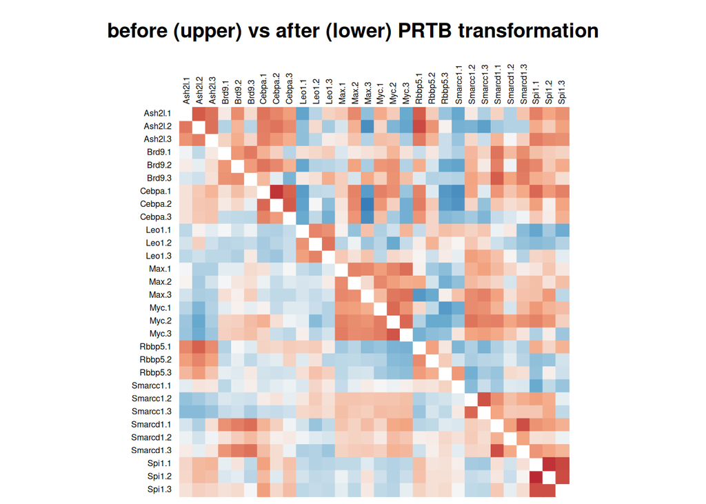

```r
selected_genes <- c("Smarcc1",
                    "Max", "Myc",
                    "Cebpa", "Spi1", "Leo1",
                    "Brd9", "Smarcd1",
                    "Ash2l", "Rbbp5")

cols_7 <- colorRampPalette(c(
  "#053061",
  "#2166AC",
  "#67A9CF",
  "#F7F7F7",
  "#F4A582",
  "#D6604D",
  "#B2182B"
))(200)

# subset and exaggerate both matrices
subset.exaggerate.cormat <- function(cormat, selected_genes, power = 0.6){
    cormat <- as.matrix(cormat)

  # escape regex metacharacters in gene names
  escape_regex <- function(x) gsub("([\\.^$|()\\[\\]{}+*?\\\\-])", "\\\\\\1", x, perl = TRUE)

  # build regex pattern
  pat <- paste0("^(", paste(escape_regex(selected_genes), collapse = "|"), ")", "\\.(1|2|3)$")

  rn <- rownames(cormat); cn <- colnames(cormat)
  if (is.null(rn) || is.null(cn)) stop("Matrix must have row and column names.")

  # subset to matching guides
  keep <- intersect(rn[grepl(pat, rn)], cn[grepl(pat, cn)])
  if (length(keep) < 2L) stop("Fewer than 2 matching guides found for selected_genes.")

  submat <- cormat[keep, keep, drop = FALSE]
  #exagerate for colouring
  exmat <- sign(submat) * abs(submat)^power
  #make diagonals NA
  diag(exmat) <- NA
  return(exmat)
}
sub_prtb <- subset.exaggerate.cormat(perturbation_guide_cormatrix_prtb, selected_genes, power = 0.7)
sub_sct <- subset.exaggerate.cormat(perturbation_guide_cormatrix_sct, selected_genes, power = 0.7)

# heirarchical cluster based on prtb subset
#ord <- corrplot::corrMatOrder(sub_prtb, order = "hclust")
# alphabetical order
ord <- sort(rownames(sub_prtb))
sub_prtb <- sub_prtb[ord, ord]  # lock the order
sub_sct <- sub_sct[ord, ord]  # lock the order

# plot prtb (lower)
suppressMessages(plot_exag_corrplot <- corrplot::corrplot(sub_prtb,
                                         type = "lower",
                                         order = "original",
                                         method = "color",
                                         col = cols_7,
                                         diag = TRUE,
                                         na.label = "square",
                                         na.label.col = "white",
                                         tl.cex = 0.5,
                                         tl.pos = "lt",
                                         tl.col = "black",
                                         cl.pos = "n",
                                         mar = c(0, 0, 3, 0),
                                         main = "before (upper) vs after (lower) PRTB transformation"))

# plot sct (upper)
suppressMessages(plot_exag_corrplot <- corrplot::corrplot(sub_sct,
                                         type = "upper",
                                         order = "original",
                                         method = "color",
                                         col = cols_7,
                                         diag = TRUE,
                                         add = TRUE,
                                         na.label = "square",
                                         na.label.col = "white",
                                         tl.cex = 0.5,
                                         tl.pos = "n",
                                         tl.col = "black",
                                         cl.pos = "n"))
```

## 2.5 ARI before/after PRTB

```r
# Function to calculate Adjusted-Rand-Index
guide_clustering_ari <- function(dist_mat, selected_genes = NULL) {
  # need mclust for adjustedRandIndex
  if (!requireNamespace("mclust", quietly = TRUE)) {
    stop("Package 'mclust' is required but not installed.")
  }

  # ensure matrix
  dist_mat <- as.matrix(dist_mat)

  rn <- rownames(dist_mat)
  cn <- colnames(dist_mat)
  if (is.null(rn) || is.null(cn)) {
    stop("Distance matrix must have row and column names.")
  }

  # optional subsetting to selected genes
  if (!is.null(selected_genes)) {
    # escape regex metacharacters in gene names
    escape_regex <- function(x) {
      gsub("([\\.^$|()\\[\\]{}+*?\\\\-])", "\\\\\\1", x, perl = TRUE)
    }

    # build regex pattern: Gene.(1|2|3)
    pat <- paste0(
      "^(",
      paste(escape_regex(selected_genes), collapse = "|"),
      ")",
      "\\.(1|2|3)$"
    )

    keep <- intersect(rn[grepl(pat, rn)], cn[grepl(pat, cn)])
    if (length(keep) < 2L) {
      stop("Fewer than 2 matching guides found for selected_genes.")
    }

    dist_mat <- dist_mat[keep, keep, drop = FALSE]
    rn <- rownames(dist_mat)  # update
  }

  # infer gene labels from rownames, e.g. "Abl1.1" -> "Abl1"
  gene_for_guide <- sub("\\.[^.]+$", "", rn)
  n_genes <- length(unique(gene_for_guide))
  if (n_genes < 2L) {
    stop("Fewer than 2 genes present; ARI not meaningful.")
  }

  # hierarchical clustering on distance matrix
  d  <- as.dist(dist_mat)
  hc <- hclust(d, method = "complete")

  clusters <- cutree(hc, k = n_genes)

  # Adjusted Rand Index between true gene labels and cluster labels
  mclust::adjustedRandIndex(gene_for_guide, clusters)
}

# on whole data set
guide_clustering_ari(perturbation_guide_distmatrix_sct)
```

```
## [1] 0.00411105
```

```r
guide_clustering_ari(perturbation_guide_distmatrix_prtb)
```

```
## [1] 0.02528063
```

```r
# on selected genes in heatmap
guide_clustering_ari(perturbation_guide_distmatrix_sct, selected_genes = selected_genes)
```

```
## [1] 0.4621554
```

```r
guide_clustering_ari(perturbation_guide_distmatrix_prtb, selected_genes = selected_genes)
```

```
## [1] 0.6075188
```

# 3 SGS score

- Define **SGS - Same Gene Similarity** score for each guide as (distances to guides targeting same gene) / (distances to all other guides)
- Summarise to get SGS scores for each gene
- Filter by SGS scores for input to make perturbation embedding

```r
# define function to calculate SGS score
calculate_SGS <- function(distmat, index) {
  # parse gene names from guide IDs (strip trailing .digits)
  guides <- colnames(distmat)
  genes  <- sub("\\.\\d+$", "", guides)

  # current guide/gene
  guide_i <- guides[index]
  gene_i <- genes[index]

  # indices of same-gene guides
  same_gene_idx <- which(genes == gene_i)

  # paired = same-gene except itself
  paired_idx <- setdiff(same_gene_idx, index)

  # if no pair exists, score is NA (cannot compute within-gene avg)
 if (length(paired_idx) == 0L) {
    score <- NA_real_
  } else {

  # other = everything not in this gene
  other_idx <- setdiff(seq_len(ncol(distmat)), same_gene_idx)

  # compute means (NA-robust)
  avg_same <- mean(distmat[index, paired_idx], na.rm = TRUE)
  avg_other <- mean(distmat[index, other_idx], na.rm = TRUE)

  # calculate score
  score <- avg_same / avg_other
  }

  SGS_result <- c(guide_i, gene_i, score)
  return(SGS_result)
}

## ------ PRTB assay -------
#indices of all non-control guides
non_nt_idx <- which(!grepl("NO\\.SITE\\.|ONE\\.INTERGENIC\\.", colnames(perturbation_guide_distmatrix_prtb)))

# calculate SGS for all targeting guides
res <- vapply(
  non_nt_idx,
  function(i) calculate_SGS(perturbation_guide_distmatrix_prtb, i),
  FUN.VALUE = character(3L))
res <- t(res)
SGS_guide_prtb <- data.frame(
  Guide     = res[, 1],
  Gene      = res[, 2],
  SGS_score = suppressWarnings(as.numeric(res[, 3]))
)
SGS_gene_prtb <- SGS_guide_prtb %>%
  group_by(Gene) %>%
  summarise(Average_SGS = mean(SGS_score))

## ------ SCT assay -------
#indices of all targeting guides
non_nt_idx <- which(!grepl("NO\\.SITE\\.|ONE\\.INTERGENIC\\.", colnames(perturbation_guide_distmatrix_sct)))
# calculate SGS
res <- vapply(
  non_nt_idx,
  function(i) calculate_SGS(perturbation_guide_distmatrix_sct, i),
  FUN.VALUE = character(3L))
res <- t(res)
SGS_guide_sct <- data.frame(
  Guide     = res[, 1],
  Gene      = res[, 2],
  SGS_score = suppressWarnings(as.numeric(res[, 3]))
)
SGS_gene_sct <- SGS_guide_sct %>%
  group_by(Gene) %>%
  summarise(Average_SGS = mean(SGS_score))
```

## 3.1 Simulate distributions from non-targeting guides

```r
set.seed(50)
# indexes of non-targeting guides (same in prtb and sct)
nt_idx <- which(grepl("NO\\.SITE\\.|ONE\\.INTERGENIC\\.", colnames(perturbation_guide_distmatrix_sct)))


## -------- Define functions-------- ####
fake_SGS <- function(distmat, index) {
  # indexes of other nt guides
  nt_idx <- which(grepl("NO\\.SITE\\.|ONE\\.INTERGENIC\\.", colnames(distmat)))

  # selected guide
  guides <- colnames(distmat)
  guide_i <- guides[index]

  # random pairing
  pool <- setdiff(nt_idx, index)
  pair_idx <- sample(pool, 2)

  # other = everything not this guide or paired
  other_idx <- setdiff(seq_len(ncol(distmat)), index)
  other_idx <- setdiff(other_idx, pair_idx)

  # compute means (NA-robust)
  avg_same <- mean(distmat[index, pair_idx], na.rm = TRUE)
  avg_other <- mean(distmat[index, other_idx], na.rm = TRUE)

  # calculate score
  score <- avg_same / avg_other

  SGS_result <- c(guide_i, score)
  return(SGS_result)
}
fake_SGS_gene <- function(distmat, index,
                          nt_patterns = c("NO\\.SITE\\.", "ONE\\.INTERGENIC\\."),
                          sep = "|") {
  # all NT indices
  guides <- colnames(distmat)
  nt_idx <- which(grepl(paste(nt_patterns, collapse = "|"), guides))

  # pick 2 other NTs to pair with 'index'
  pool <- setdiff(nt_idx, index)
  pair_idx <- sample(pool, 2)

  # fake gene set of 3 NT guigdes
  fake_set <- c(index, pair_idx)
  fake_guides <- guides[fake_set]

  # helper: SGS for one member j of the fake set
  sgs_one <- function(j) {
    same_idx  <- setdiff(fake_set, j)
    other_idx <- setdiff(seq_len(ncol(distmat)), fake_set)
    if (length(other_idx) == 0L) return(NA_real_)
    avg_same  <- mean(distmat[j, same_idx],  na.rm = TRUE)
    avg_other <- mean(distmat[j, other_idx], na.rm = TRUE)
    if (!is.finite(avg_other) || avg_other == 0) return(NA_real_)
    avg_same / avg_other
  }

  # SGS for each of the 3, then mean
  scores <- vapply(fake_set, sgs_one, numeric(1))
  mean_SGS <- mean(scores, na.rm = TRUE)

  SGS_result <- c(paste(fake_guides, collapse = sep), mean_SGS)
  return(SGS_result)
}

## -------- Generate NULL distribution SCT -------- ####
# "guide" fake SGS - SCT
res <- vapply(
  rep(nt_idx, 10),
  function(i) fake_SGS(perturbation_guide_distmatrix_sct, i),
  FUN.VALUE = character(2L))
res <- t(res)
fake_SGS_guide_sct <- data.frame(
  control_guide     = res[, 1],
  fake_SGS      = res[, 2]
  )
q05_guide_sct <- quantile(as.numeric(fake_SGS_guide_sct$fake_SGS), probs = 0.05)
q05_guide_sct
```

```
##        5%
## 0.8276117
```

```r
# "gene" fake SGS - SCT
res <- vapply(
  rep(nt_idx, 10),
  function(i) fake_SGS_gene(perturbation_guide_distmatrix_sct, i),
  FUN.VALUE = character(2L))
res <- t(res)
fake_SGS_gene_sct <- data.frame(
  fake_gene     = res[, 1],
  fake_avg_SGS      = res[, 2]
  )
q05_gene_sct <- quantile(as.numeric(fake_SGS_gene_sct$fake_avg_SGS), probs = 0.05)
q05_gene_sct
```

```
##        5%
## 0.8413252
```

```r
## -------- Generate NULL distribution PRTB  -------- ####
# "guide" fake SGS - prtb
res <- vapply(
  rep(nt_idx, 10),
  function(i) fake_SGS(perturbation_guide_distmatrix_prtb, i),
  FUN.VALUE = character(2L))
res <- t(res)
fake_SGS_guide_prtb <- data.frame(
  control_guide     = res[, 1],
  fake_SGS      = res[, 2]
  )
q05_guide_prtb <- quantile(as.numeric(fake_SGS_guide_prtb$fake_SGS), probs = 0.05)
q05_guide_prtb
```

```
##        5%
## 0.9600689
```

```r
# "gene" fake SGS - prtb
res <- vapply(
  rep(nt_idx, 10),
  function(i) fake_SGS_gene(perturbation_guide_distmatrix_prtb, i),
  FUN.VALUE = character(2L))
res <- t(res)
fake_SGS_gene_prtb <- data.frame(
  fake_gene = res[, 1],
  fake_avg_SGS = res[, 2]
  )
q05_gene_prtb <- quantile(as.numeric(fake_SGS_gene_prtb$fake_avg_SGS), probs = 0.05)
q05_gene_prtb
```

```
##        5%
## 0.9672063
```

## 3.2 plot real vs fake

- Set a threshold at 95% of the fake SGS scores

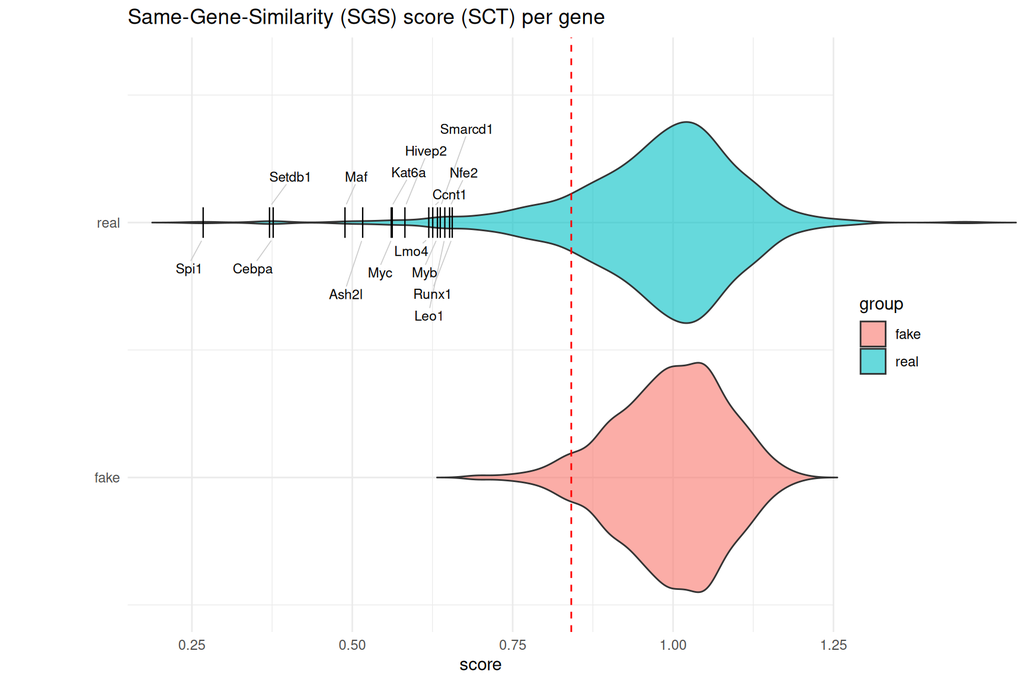

```r
plot_sgs_violin <- function(real_scores, fake_scores, q05,
                            title = "SGS scores",
                            SGS_df,
                            gene_col  = "Gene",
                            score_col = "Average_Score",
                            label_top_n    = 10,
                            tick_half_width = 0.06,
                            label_x_offset  = 0.12,
                            label_size      = 3) {

  # Data: fake (x = 1) then real (x = 2)
  group <- factor(c(rep("fake", length(fake_scores)),
                    rep("real", length(real_scores))),
                  levels = c("fake", "real"))
  df <- data.frame(
    x_num = as.numeric(group),  # 1 for fake, 2 for real
    group = group,
    score = c(fake_scores, real_scores)
  )
  x_real <- 2  # numeric x position for the "real" violin

  # Base plot
  p <- ggplot(df, aes(x = x_num, y = score, group = group, fill = group)) +
    geom_violin(trim = FALSE, alpha = 0.6) +
    geom_hline(yintercept = q05, linetype = "dashed", color = "red") +
    scale_x_continuous(breaks = c(1, 2), labels = c("fake", "real")) +
    labs(title = title, x = NULL, y = "score") +
    theme_minimal()

  # ---- Top-N lowest-scoring genes ----
  stopifnot(all(c(gene_col, score_col) %in% names(SGS_df)))
  keep  <- is.finite(SGS_df[[score_col]])
  marks <- SGS_df[keep, c(gene_col, score_col), drop = FALSE]
  names(marks) <- c("label","score")
  marks <- head(marks[order(marks$score, decreasing = FALSE), , drop = FALSE], label_top_n)

  if (nrow(marks) > 0) {
    # Tick positions around the "real" violin
    marks$xmin <- x_real - tick_half_width
    marks$xmax <- x_real + tick_half_width

    # Alternate sides, anchor at tick ends, and nudge outward
    marks$side     <- rep(c("left","right"), length.out = nrow(marks))
    marks$x_anchor <- ifelse(marks$side == "left",  marks$xmin, marks$xmax)
    marks$nudge_x  <- ifelse(marks$side == "left", -label_x_offset, label_x_offset)
    marks$hjust    <- ifelse(marks$side == "left", 1, 0)

    # Draw horizontal ticks
    p <- p + geom_segment(
      data = marks,
      aes(x = xmin, xend = xmax, y = score, yend = score),
      inherit.aes = FALSE,
      color = "black",
      linewidth = 0.4
    )

    # Repelled labels (leaders from tick ends)
    p <- p + ggrepel::geom_text_repel(
      data = marks,
      aes(x = x_anchor, y = score, label = label),
      inherit.aes        = FALSE,
      nudge_x            = marks$nudge_x,
      nudge_y            = 0,
      direction          = "y",
      hjust              = marks$hjust,
      box.padding        = 0.25,
      point.padding      = 0.2,
      min.segment.length = 0,
      segment.size       = 0.3,
      segment.color      = "grey80",
      size               = label_size,
      seed               = 42
    )

    # Keep both violins visible + labels, but now with flipped coords
    ext <- label_x_offset + 0.5
    p <- p +
      coord_flip(ylim = c(0.2, 1.2),
                 xlim = c(0.5, x_real + ext),
                 clip = "off") +
      theme(plot.margin = unit(c(5.5, 60, 5.5, 60), "pt"))

  } else {
    # If there are no marks, still flip the axes
    p <- p + coord_flip()
  }
  p
}

p_prtb_gene <- plot_sgs_violin(
  real_scores = as.numeric(SGS_gene_prtb$Average_SGS),
  fake_scores = as.numeric(fake_SGS_gene_prtb$fake_avg_SGS),
  q05         = q05_gene_prtb,
  title       = "Same-Gene-Similarity (SGS) score (PRTB) per gene",
  SGS_df      = SGS_gene_prtb,
  score_col = "Average_SGS",
  label_top_n = 15,
  label_x_offset = 0.12
)
p_sct_gene <- plot_sgs_violin(
  real_scores = as.numeric(SGS_gene_sct$Average_SGS),
  fake_scores = as.numeric(fake_SGS_gene_sct$fake_avg_SGS),
  q05         = q05_gene_sct,
  title       = "Same-Gene-Similarity (SGS) score (SCT) per gene",
  SGS_df      = SGS_gene_sct,
  score_col = "Average_SGS",
  label_top_n = 15,
  label_x_offset = 0.12
)
p_sct_gene
```

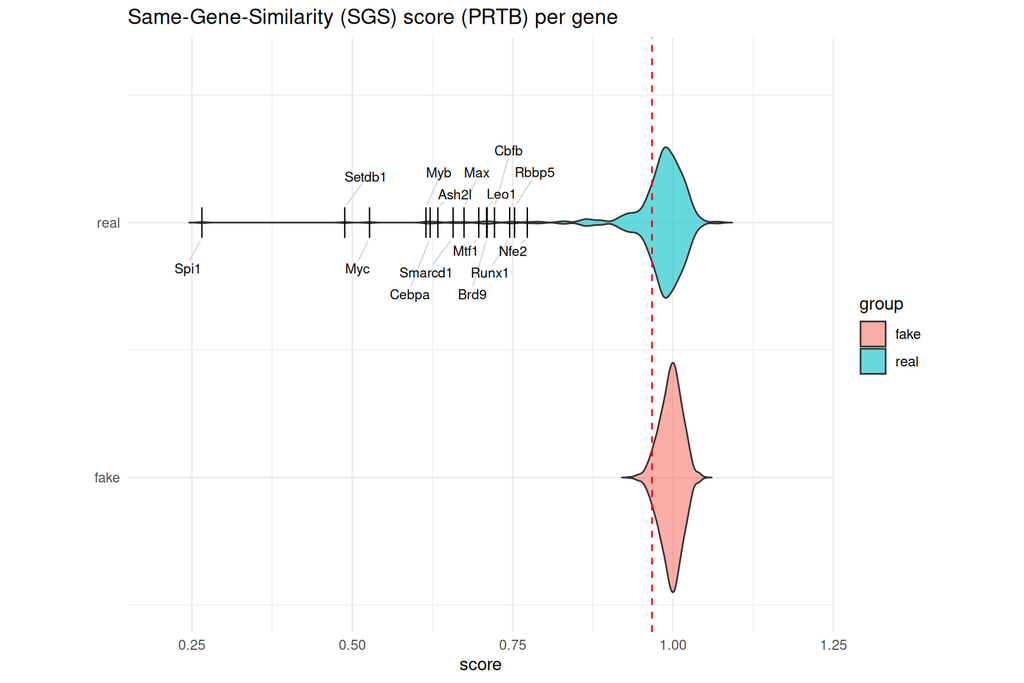

```r
p_prtb_gene
```

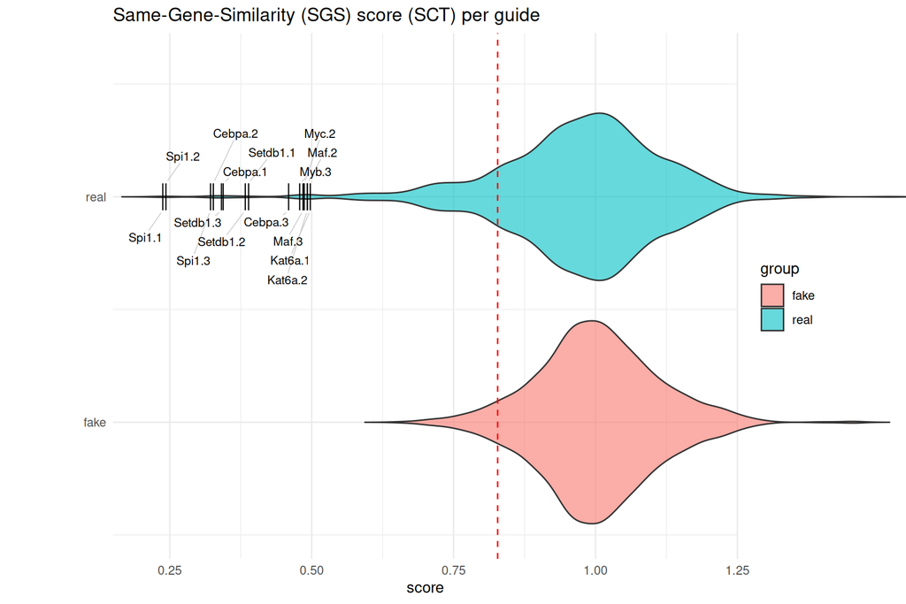

```r
p_sct_guide <- plot_sgs_violin(
  real_scores = as.numeric(SGS_guide_sct$SGS_score),
  fake_scores = as.numeric(fake_SGS_guide_sct$fake_SGS),
  q05         = q05_guide_sct,
  title       = "Same-Gene-Similarity (SGS) score (SCT) per guide",
  gene_col  = "Guide",
  SGS_df      = SGS_guide_sct,
  score_col = "SGS_score",
  label_top_n = 15,
  label_x_offset = 0.12
)

p_prtb_guide <- plot_sgs_violin(
  real_scores = as.numeric(SGS_guide_prtb$SGS_score),
  fake_scores = as.numeric(fake_SGS_guide_prtb$fake_SGS),
  q05         = q05_guide_prtb,
  title       = "Same-Gene-Similarity (SGS) score (PRTB) per guide",
  gene_col  = "Guide",
  SGS_df      = SGS_guide_prtb,
  score_col = "SGS_score",
  label_top_n = 15,
  label_x_offset = 0.12
)
p_sct_guide
```

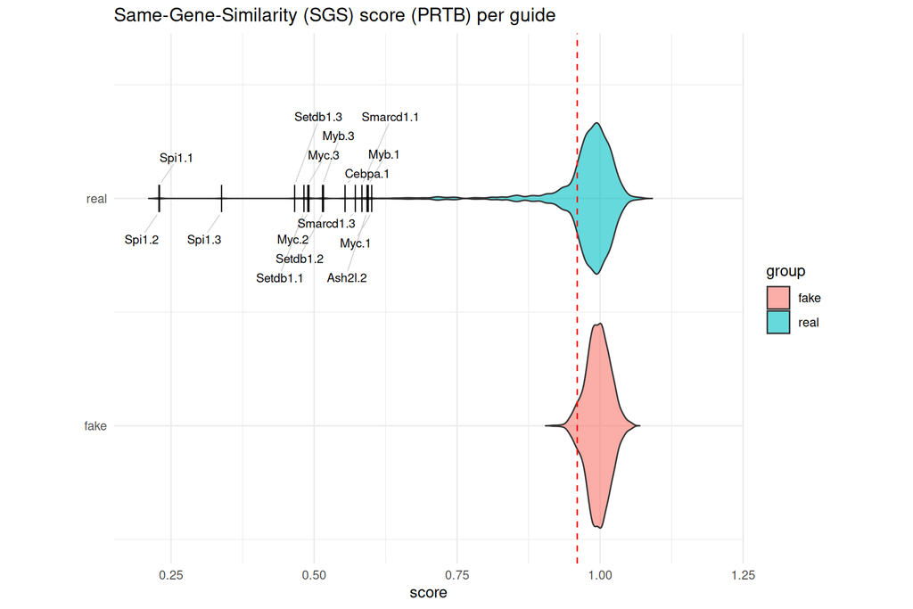

```r
p_prtb_guide
```

```r
ggsave( filename = "manuscript/figs/SGS_score_violin_gene.pdf",
        plot     = p_prtb_gene,
        width    = 10,
        height   = 3,
        units    = "in"
        )
ggsave( filename = "manuscript/figs/SGS_score_violin_guide.pdf",
        plot     = p_prtb_guide,
        width    = 10,
        height   = 3,
        units    = "in"
        )
```

## 3.3 Subset to only consistent genes and guides

```r
# Filter genes
SGS_gene_prtb_filt <- subset(SGS_gene_prtb,
                            Average_SGS < q05_gene_prtb)

# Filter guides
SGS_guide_prtb_filt <- subset(SGS_guide_prtb,
                              SGS_score < q05_guide_prtb)
```

```r
# Write file of only filtered genes
write.csv(SGS_gene_prtb_filt,
          file = sprintf("manuscript/int_files/SGS_gene_prtb_filt_%s.csv", cortest_to_use),
          row.names = FALSE)

# Write file of only filtered guides
write.csv(SGS_guide_prtb_filt,
          file = sprintf("manuscript/int_files/SGS_guide_prtb_filt_%s.csv", cortest_to_use),
          row.names = FALSE)
```

```r
# ----- Filter perturbations_by_features_guide by guide -------
perturbations_by_features_guide_prtb_filt <-  perturbations_by_features_guide_prtb[,
                                                    colnames(perturbations_by_features_guide_prtb) %in% SGS_guide_prtb_filt$Guide]

# make corr matrix (guide-only)
cor_guide <- cor(
  perturbations_by_features_guide_prtb_filt,
  method = cortest_to_use,
  use = "pairwise.complete.obs"
)

# rename to add test
assign(paste0("perturbation_guide_prtb_filtguideonly_cor_", cortest_to_use), cor_guide)

# ----- Filter perturbations_by_features_guide by gene -------
base_gene_names <- sub("\\..*", "", colnames(perturbations_by_features_guide_prtb))
cols_to_keep <- base_gene_names %in% SGS_gene_prtb_filt$Gene
perturbations_by_features_guide_prtb_filtgene <- perturbations_by_features_guide_prtb[, cols_to_keep, drop = FALSE]

if (ncol(perturbations_by_features_guide_prtb_filtgene) < 2L) {
  stop("After gene filter: need at least 2 columns to compute a correlation matrix.")
}

# make corr matrix (guide + gene filtered)
cor_gene <- cor(
  perturbations_by_features_guide_prtb_filtgene,
  method = cortest_to_use,
  use = "pairwise.complete.obs"
)

# rename to add test
assign(paste0("perturbation_guide_prtb_filtgene_cor_", cortest_to_use), cor_gene)

# ----- Filter perturbations_by_features_guide by gene and guide -------
base_gene_names <- sub("\\..*", "", colnames(perturbations_by_features_guide_prtb_filt))
cols_to_keep <- base_gene_names %in% SGS_gene_prtb_filt$Gene
perturbations_by_features_guide_prtb_filt <- perturbations_by_features_guide_prtb_filt[, cols_to_keep, drop = FALSE]

if (ncol(perturbations_by_features_guide_prtb_filt) < 2L) {
  stop("After gene filter: need at least 2 columns to compute a correlation matrix.")
}

# make corr matrix (guide + gene filtered)
cor_gene <- cor(
  perturbations_by_features_guide_prtb_filt,
  method = cortest_to_use,
  use = "pairwise.complete.obs"
)

# rename to add test
assign(paste0("perturbation_guide_prtb_filtguide_gene_cor_", cortest_to_use), cor_gene)
```

```r
# save correlation matrices as csv files
write.csv(
  cor_guide,
  file = sprintf("manuscript/int_files/perturbation_guide_prtb_filtguideonly_cor_%s.csv", cortest_to_use),
  row.names = TRUE
)

write.csv(
  cor_gene,
  file = sprintf("manuscript/int_files/perturbation_guide_prtb_filtguide_gene_cor_%s.csv", cortest_to_use),
  row.names = FALSE
  )
```

# 4 Plot stylised correlation matrix

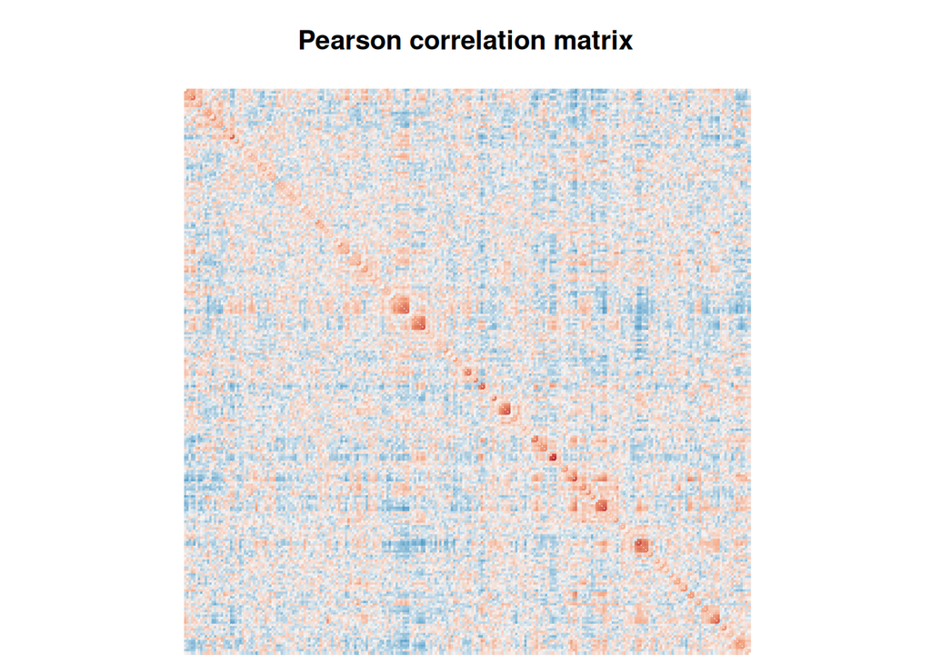

```r
# heirarchical cluster based on prtb subset
ord <- corrplot::corrMatOrder(cor_gene, order = "hclust")
cor_gene <- cor_gene[ord, ord]  # lock the order

cor_gene_exag <- sign(cor_gene) * abs(cor_gene)^0.6
stylised_corr_matrix <- suppressMessages(corrplot::corrplot(cor_gene_exag,
                                    type = "full",
                                    order = "original",
                                    method = "color",
                                    col = cols_7,
                                    diag = FALSE,
                                    na.label = "square",
                                    na.label.col = "white",
                                    tl.cex = 0.5,
                                    tl.pos  = "n",
                                    cl.pos = "n",
                                    mar = c(0, 0, 3, 0),
                                    main = "Pearson correlation matrix"))
```